# Ted Laderas, PhD

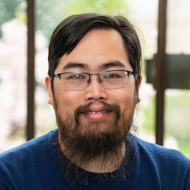

I am the Director of Training and Community (formerly a Community Organizer) at the [Fred Hutch Cancer Center](https://www.fredhutch.org/en.html) in the [Data Science Lab (DaSL)](https://hutchdatascience.org/). I’ve worked previously at [DNAnexus](https://www.dnanexus.com/) as a bioinformatics trainer and [Oregon Health & Science University](https://ohsu.edu/dmice) as a postdoc and Assistant Professor.

Over 12 years of teaching, I’ve trained learners in many topics, including Machine Learning, the DNAnexus cloud-based genomics platform, R and the Tidyverse, and Shiny. I’ve given webinars to empower users of the [UK Biobank Research Analysis Platform](https://www.youtube.com/playlist?list=PLRkZ0Fz-n3Z7Jg0Vz4vudLYnBza4EUGLM), as well as authoring the book [Bash for Bioinformatics](https://laderast.github.io/bash_for_bioinformatics/) and my Introductory [Ready for R](https://ready4r.netlify.app) Course. In my spare time, I’m also a Data Science Mentor for [Posit Academy](https://posit.co/products/enterprise/academy/), helping data apprentices learn Tidyverse and Python. I also wrestle with a cello to make ambient music.

Collaboration, training, and team science are passions of mine. I believe that research should not be lonely, and building communities of practice in science and research that are psychologically safe and inclusive are the key to doing better, more robust science. To this end, I use evidence based pedagogy, especially utilizing the concepts of psychological safety and active learning. I am a certified instructor for both [The Carpentries](https://carpentries.org/) and [Posit Academy](https://posit.co/products/enterprise/academy/).

My free [Ready for R](https://ready4r.netlify.app) course currently is at over 1800 external users, and I have built a learning community and [mailing list](https://buttondown.email/ready4r/) around the course. The course has been lauded by users as being more inclusive and less intimidating than other R courses.

Note: I am no longer on Twitter. [The Twitter link](https://laderast.github.io/tweets) goes to an archive of my tweets, including [my most popular ones](https://laderast.github.io/tweets/popular/).

[Twitter](https://laderast.github.io/tweets) [LinkedIn](https://www.linkedin.com/in/ted-laderas-0714a92/) [GitHub](https://github.com/laderast) [Mastodon](https://vmst.io/@tladeras)